# Assignment 01

```r
indata <- read.csv("D:/RStudio/File/STATS413/vwjetta_gas.csv")
indata$mileage[indata$mileage == 999999] <- NA
indata$vehage[indata$vehage == 999] <- NA
indata$mpg[indata$mpg == 99] <- NA

indata$congrade <- factor(indata$congrade)
levels(indata$congrade) <- c("rough", "average", "clean","excellent")
```

## Question a

- Use the summary function to get variable summaries after recoding missing values and declaring congrade as a factor with four levels
- How many values are missing on mileage? on vehage? on mpg?

```r
summary(indata)
```

```
##     resratio         mileage           vehage            mpg
##  Min.   :0.0388   Min.   :  1266   Min.   :  1.00   Min.   :22.00
##  1st Qu.:0.1982   1st Qu.: 30578   1st Qu.: 32.00   1st Qu.:23.00
##  Median :0.3425   Median : 63744   Median : 64.00   Median :25.00
##  Mean   :0.4224   Mean   : 64398   Mean   : 65.88   Mean   :24.06
##  3rd Qu.:0.6378   3rd Qu.: 95131   3rd Qu.: 97.00   3rd Qu.:25.00
##  Max.   :1.0535   Max.   :149769   Max.   :164.00   Max.   :27.00
##                   NA's   :5        NA's   :8        NA's   :6
##       congrade      modelyr
##  rough    :578   Min.   :1997
##  average  :378   1st Qu.:2003
##  clean    :209   Median :2005
##  excellent: 31   Mean   :2005
##                  3rd Qu.:2008
##                  Max.   :2011
##
```

- 5 values are missing in **mileage**
- 8 values are missing in **vehage**
- 6 values are missing in **mpg**

## Question b

- How many vehicles are there with condition grade equal to rough, average, clean, and excellent? In other words, give the frequency distribution of congrade.

```r
table(indata$congrade)
```

```
##
##     rough   average     clean excellent
##       578       378       209        31
```

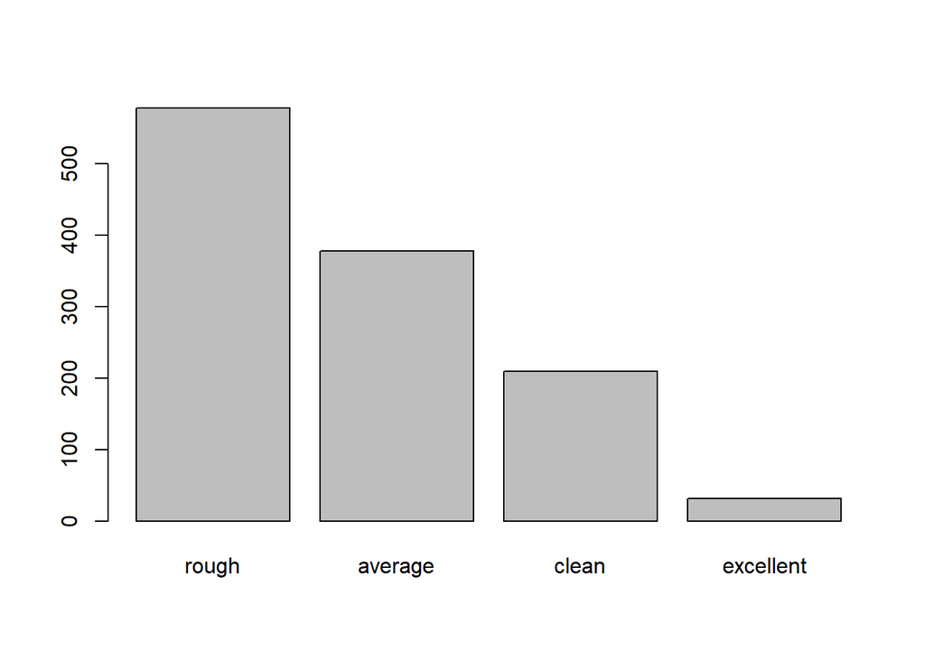

```r
plot(indata$congrade)
```

## Question c

- Make a matrix scatter plot of the variables resratio, mileage, and vehage.

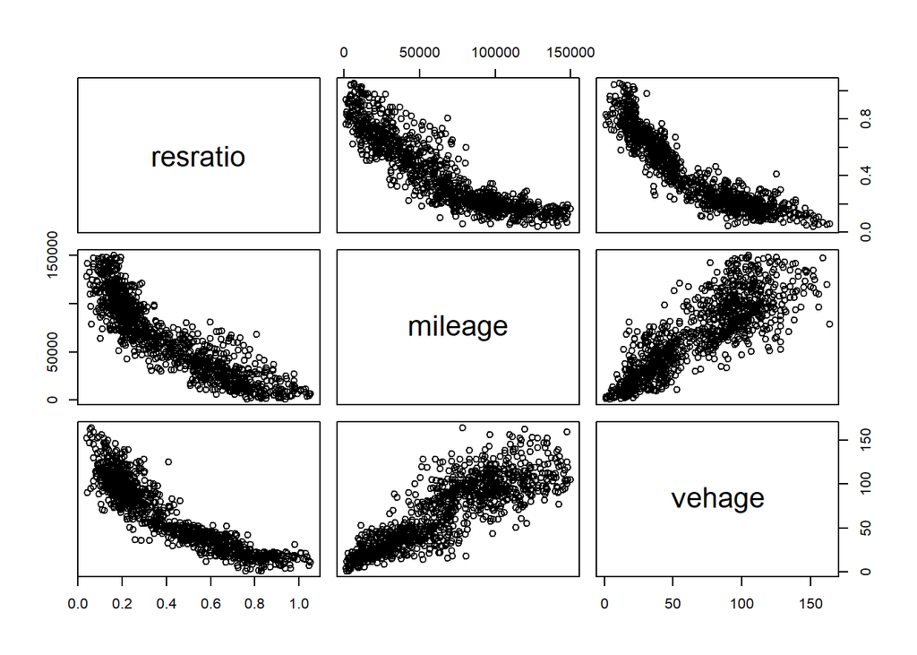

```r
pairs(indata[,c("resratio", "mileage", "vehage")])
```

## Question d

- Make side-by-side boxplots of resratio by the levels of congrade. Calculate the mean resratio by the levels of congrade.

```r
rough_vehicles <- indata[indata$congrade == "rough",]
average_vehicles <- indata[indata$congrade == "average",]
clean_vehicles <- indata[indata$congrade == "clean",]
excellent_vehicles <- indata[indata$congrade == "excellent",]

par(mfcol = c(2,1))
boxplot(rough_vehicles$resratio, average_vehicles$resratio, clean_vehicles$resratio, excellent_vehicles$resratio)

mean_resratio_rough <- mean(rough_vehicles$resratio)
mean_resratio_average <- mean(average_vehicles$resratio)
mean_resratio_clean <- mean(clean_vehicles$resratio)
mean_resratio_excellent <- mean(excellent_vehicles$resratio)

cat("mean resratio of rough:", mean_resratio_rough)
```

```
## mean resratio of rough: 0.2722137
```

```r
cat("mean resratio of average:", mean_resratio_average)
```

```
## mean resratio of average: 0.4774244
```

```r
cat("mean resratio of clean:", mean_resratio_clean)
```

```
## mean resratio of clean: 0.6732804
```

```r
cat("mean resratio of excellent:", mean_resratio_excellent)
```

```
## mean resratio of excellent: 0.8596422
```

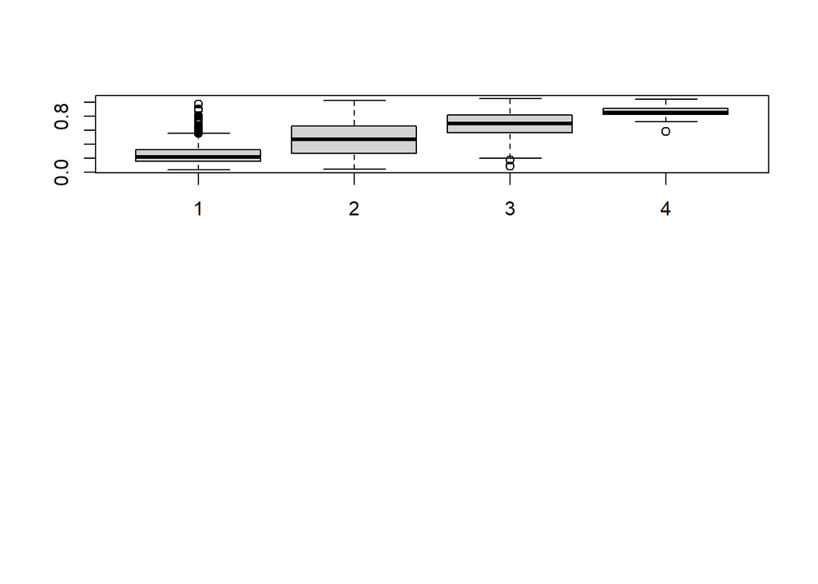

## Question e

- Make a histogram and a kernel density plot of the variable resratio for vehicles with mileage greater than 100,000.
- (Note that mileage has missing values).
- Comment on the shape of this distribution. Calculate the mean and standard deviation of resratio for vehicles with mileage greater than 100,000.

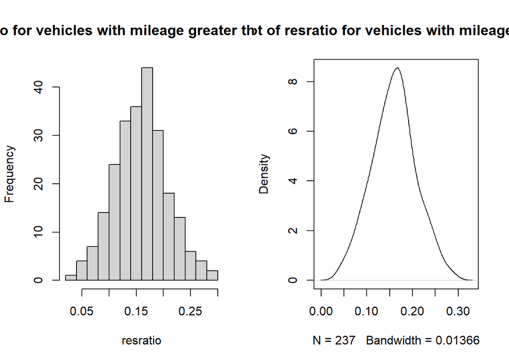

```r
mileage_limit <- indata[indata$mileage > 100000,]

resratio_mileage <- mileage_limit$resratio

par(mfrow = c(1,2))
hist(resratio_mileage, main = "resratio for vehicles with mileage greater than 100,000", xlab = "resratio", ylab = "Frequency")

plot(density(resratio_mileage,na.rm = TRUE), main = "kernel density plot of resratio for vehicles with mileage greater than 100,000")
```

```r
print("The distribution is close to normal distribution")
```

```
## [1] "The distribution is close to normal distribution"
```

```r
mean_resratio <- mean(resratio_mileage, na.rm = TRUE)
cat("mean of resratio for vehicles with mileage greater than 100,000 is:", mean_resratio)
```

```
## mean of resratio for vehicles with mileage greater than 100,000 is: 0.1593309
```

```r
std_resratio <- sd(resratio_mileage, na.rm =  TRUE)

cat("standard deviation of resratio for vehicles with mileage greater than 100,000 is:", std_resratio)
```

```
## standard deviation of resratio for vehicles with mileage greater than 100,000 is: 0.04841774
```

## Question f

```r
indata$mile15 <- indata$mileage/150000

ave_vehicle <- indata[indata$congrade == "average",]
mean_average_resratio_edit <- mean(ave_vehicle$resratio)
sd_average_resratio_edit <- sd(ave_vehicle$resratio)

cat("the mean for resratio is:", mean_average_resratio_edit)
```

```
## the mean for resratio is: 0.4774244
```

```r
cat("the standard deviation for resratio is:", sd_average_resratio_edit)
```

```
## the standard deviation for resratio is: 0.2266965
```

```r
mean_average_mile15_edit <- mean(ave_vehicle$mile15, na.rm = TRUE)
sd_average_mile15_edit <- sd(ave_vehicle$mile15, na.rm = TRUE)

cat("the mean for resratio is:", mean_average_mile15_edit)
```

```
## the mean for resratio is: 0.3651413
```

```r
cat("the standard deviation for resratio is:", sd_average_mile15_edit)
```

```
## the standard deviation for resratio is: 0.2220556
```

```r
mean_average_vehage_edit <- mean(ave_vehicle$vehage, na.rm = TRUE)
sd_average_vehage_edit <- sd(ave_vehicle$vehage, na.rm = TRUE)

cat("the mean for resratio is:", mean_average_vehage_edit)
```

```
## the mean for resratio is: 58.17772
```

```r
cat("the standard deviation for resratio is:", sd_average_vehage_edit)
```

```
## the standard deviation for resratio is: 34.79075
```